# Научная презентация (индивидуальный проект часть 6)

Дисциплина:Операционные системы

Алехин Давид Андреевич

Российский университет дружбы народов, Москва, Россия

Математический институт имени Никольского, Москва, Россия

06.03.25

# Информация

## Докладчик

- Алехин Давид Андреевич
- Студент
- Студент НММбд-01-24
- Российский университет дружбы народов
- 1132246830@pfur.ru
- https://github.com/trustdef

[figure not shown]

# Вводная часть

## Актуальность

- В современном мире многие занимаются предпринимательством, поэтому важно уметь самому делать сайты.

## Цели и задачи

Сделать поддержку английского и русского языков. Разместить элементы сайта на обоих языках. Разместить контент на обоих языках. Сделать пост по прошедшей неделе. Добавить пост на тему по выбору (на двух языках).

## Материалы и методы

- https://github.com/wowchemy/starter-hugo-academic (репозиторий странички)
- hugo-extended

## Содержание исследования

Добавьте в config/_default/config.yaml настройки для двух языков: (рис. [-@fig:001]).

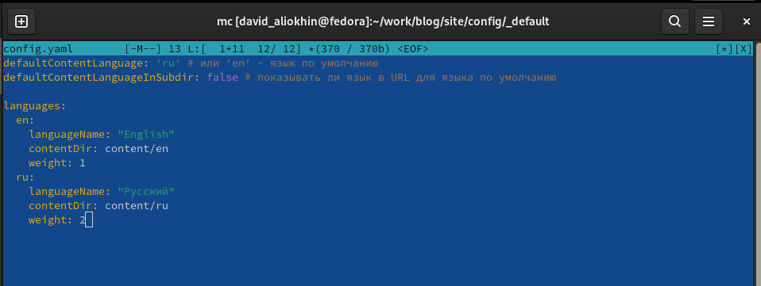

1

## Содержание исследования

Проверяю отоброжение языков (рис. [-@fig:002]).

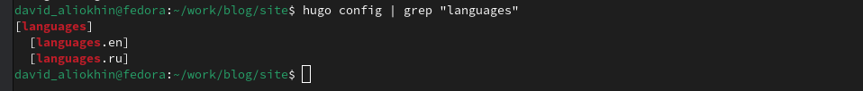

2

## Содержание исследования

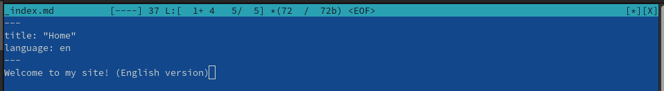

3

## Содержание исследования

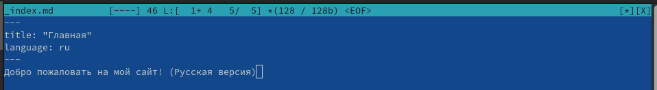

4

## Содержание исследования

Настраиваю переключение языков (рис. [-@fig:005]).

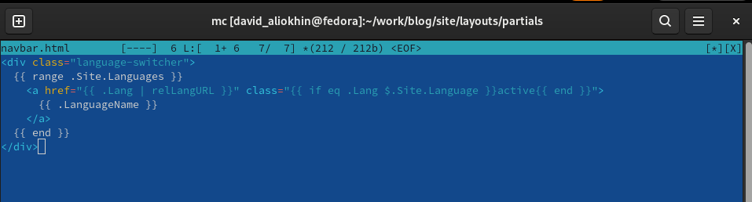

5

## Содержание исследования

Пишу пост по прошедшей неделе (2 файла на русском и английском) (рис. [-@fig:007], [-@fig:008]).

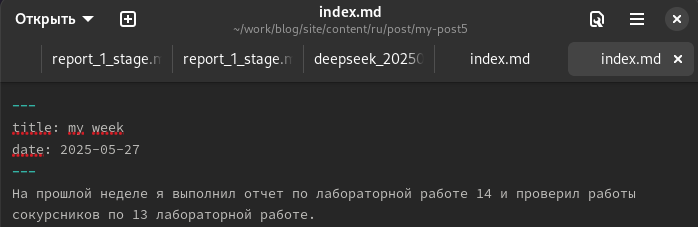

7

## Содержание исследования

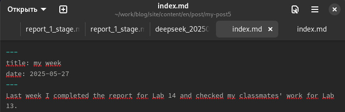

8

## Содержание исследования

Создаю пост на тему по выбору на 2х языках (рис. [-@fig:009], [-@fig:010]).

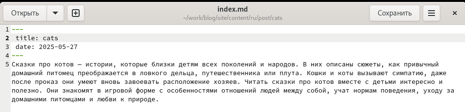

9

## Содержание исследования

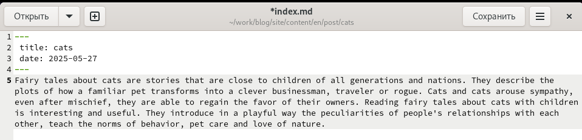

10

## Содержание исследования

Смотрю результат на разных языках (рис. [-@fig:011], [-@fig:012]).

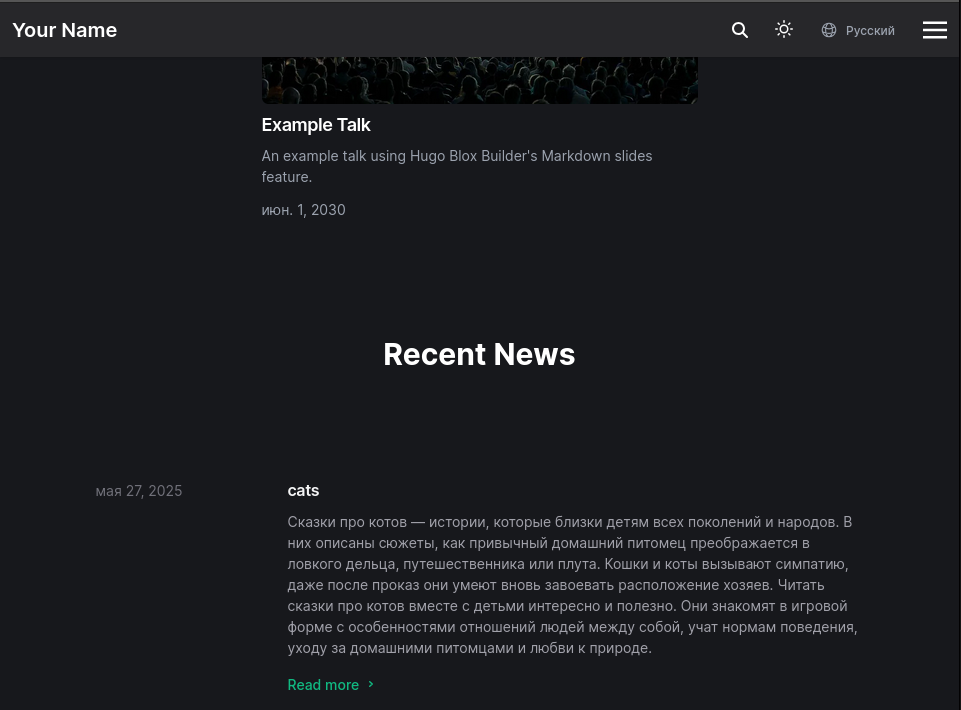

11

## Содержание исследования

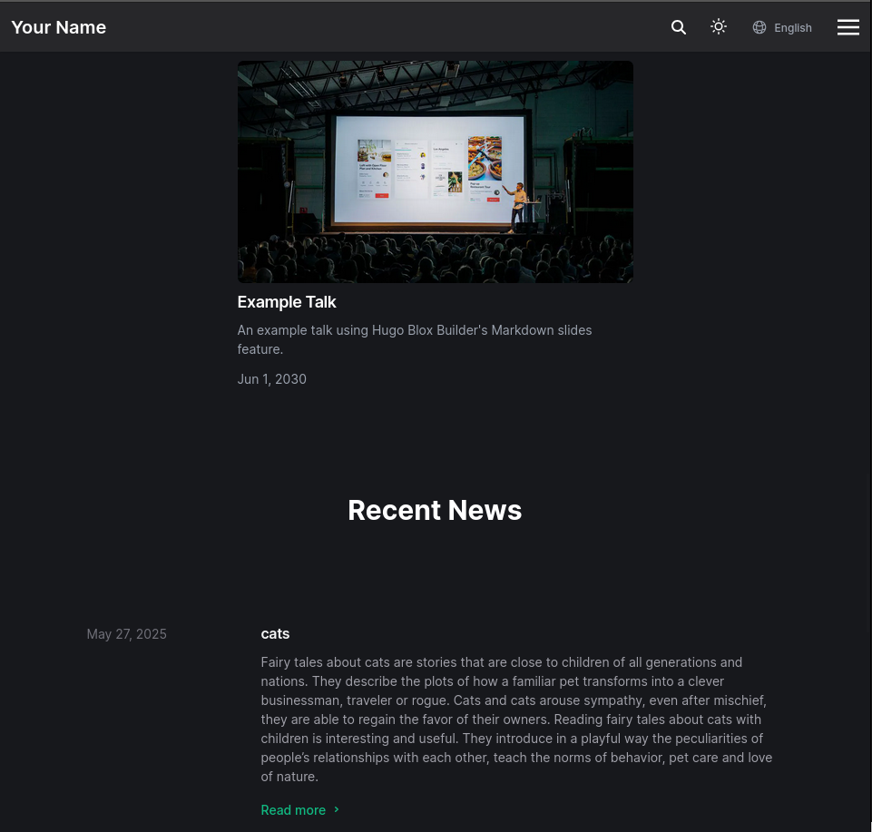

12

## Результаты

Я выполнил все задания по проекту: Сделать поддержку английского и русского языков. Разместить элементы сайта на обоих языках. Разместить контент на обоих языках. Сделать пост по прошедшей неделе. Добавить пост на тему по выбору (на двух языках).

## Итоговый слайд

В теории, теория и практика неразделимы. На практике это не так. Yoggi Berra